# Modeling

Nesse notebook, vamos coletar os dados da `VALE3`, criar conjuntos de treinamento, validação e teste e, por fim, criar uma regressão linear para prever o preço do próximo mês.

## Carregando pacotes

```r
library(tidyverse)
library(lubridate)
library(convexity)
```

## Coletando dados

|  | VALE3.SA.Open | VALE3.SA.High | VALE3.SA.Low | VALE3.SA.Close | VALE3.SA.Volume | VALE3.SA.Adjusted |
| --- | --- | --- | --- | --- | --- | --- |
| 2007-01-02 | 31.850 | 32.700 | 31.850 | 32.700 | 739800 | 21.17128 |
| 2007-01-03 | 32.255 | 32.400 | 30.795 | 31.100 | 4913000 | 20.13538 |
| 2007-01-04 | 31.000 | 31.250 | 30.150 | 30.600 | 2638600 | 19.81165 |
| 2007-01-05 | 30.540 | 30.595 | 29.100 | 29.300 | 3246000 | 18.96998 |
| 2007-01-08 | 29.500 | 30.400 | 29.500 | 30.400 | 2050600 | 19.68217 |
| 2007-01-09 | 30.430 | 30.700 | 29.155 | 29.625 | 2368200 | 19.18040 |
| 2007-01-10 | 29.200 | 30.855 | 29.005 | 30.750 | 1925600 | 19.90877 |
| 2007-01-11 | 30.405 | 31.580 | 30.375 | 30.940 | 2036800 | 20.03179 |
| 2007-01-12 | 30.975 | 31.870 | 30.850 | 31.800 | 1903600 | 20.58858 |
| 2007-01-15 | 31.900 | 32.035 | 31.725 | 31.800 | 1171400 | 20.58858 |

[output cut: 990 more lines]

## Preço médio por mês

```r
vale <- raw_vale %>%
  mutate(date = rownames(raw_vale)) %>%
  mutate(month = month(date), year = year(date)) %>%
  group_by(year, month) %>%
  summarise(mean_closing_price = mean(VALE3.SA.Close, na.rm = TRUE)) %>%
  mutate(date = date(paste0(year, "-", month, "-", "01"))) %>%
  ungroup()
vale
```

| year | month | mean_closing_price | date |
| --- | --- | --- | --- |
| 2007 | 1 | 32.330238 | 2007-01-01 |
| 2007 | 2 | 36.562778 | 2007-02-01 |
| 2007 | 3 | 36.924546 | 2007-03-01 |
| 2007 | 4 | 41.489000 | 2007-04-01 |
| 2007 | 5 | 43.521591 | 2007-05-01 |
| 2007 | 6 | 43.822000 | 2007-06-01 |
| 2007 | 7 | 46.571905 | 2007-07-01 |
| 2007 | 8 | 44.336522 | 2007-08-01 |
| 2007 | 9 | 54.355263 | 2007-09-01 |
| 2007 | 10 | 61.965908 | 2007-10-01 |

[output cut: 155 more lines]

A `VALE3` está há 165 meses na bolsa de São Paulo (~13 anos). O gráfico abaixo mostra o preço médio de fechamento ao longo desses meses.

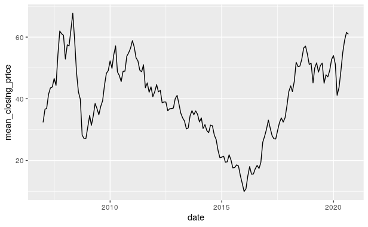

```r
ggplot(vale) +
  geom_line(aes(x=date, y=mean_closing_price))
```

## Treino, Validação e Teste

[output not shown]

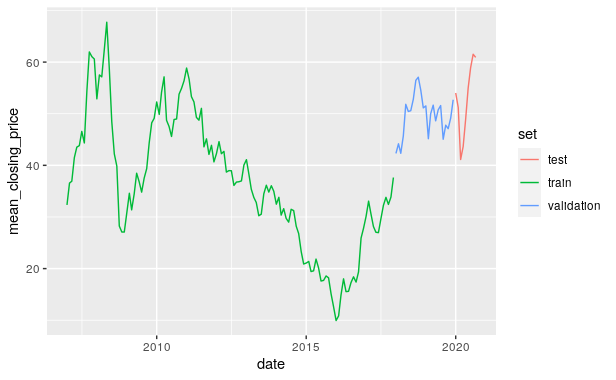

```r
splits <- vale %>%
  mutate(set = case_when(year <= 2017 ~ "train",
                         year < 2020 ~ "validation",
                         TRUE ~ "test"))
ggplot(splits) +
  geom_line(aes(x=date, y=mean_closing_price, color=set))
```

## Modelo ingênuo

Vamos implementar um modelo bastante ingênuo que se baseia no *preço médio do mês anterior* para fazer a previsão do valor médio da ação no mês seguinte.

Para isso, primeiro será necessário “computar” o preço médio do mês anterior:

```r
lagged <- splits %>%
  mutate(previous_closing_price = lag(mean_closing_price))
lagged %>%
  select(date, previous_closing_price, mean_closing_price, set)
```

| date | previous_closing_price | mean_closing_price | set |
| --- | --- | --- | --- |
| 2007-01-01 | NA | 32.330238 | train |
| 2007-02-01 | 32.330238 | 36.562778 | train |
| 2007-03-01 | 36.562778 | 36.924546 | train |
| 2007-04-01 | 36.924546 | 41.489000 | train |
| 2007-05-01 | 41.489000 | 43.521591 | train |
| 2007-06-01 | 43.521591 | 43.822000 | train |
| 2007-07-01 | 43.822000 | 46.571905 | train |
| 2007-08-01 | 46.571905 | 44.336522 | train |
| 2007-09-01 | 44.336522 | 54.355263 | train |
| 2007-10-01 | 54.355263 | 61.965908 | train |

[output cut: 155 more lines]

```r
train <- lagged %>% filter(set == "train")
model <- lm(mean_closing_price ~ previous_closing_price, data=train)
summary(model)
```

```
Call:
lm(formula = mean_closing_price ~ previous_closing_price, data = train)

Residuals:
     Min       1Q   Median       3Q      Max
-11.5373  -2.0987   0.0202   2.1672  10.2380

Coefficients:
                       Estimate Std. Error t value Pr(>|t|)
(Intercept)             1.29466    0.88218   1.468    0.145
previous_closing_price  0.96585    0.02266  42.614   <2e-16 ***
---
Signif. codes:  0 ‘***’ 0.001 ‘**’ 0.01 ‘*’ 0.05 ‘.’ 0.1 ‘ ’ 1

Residual standard error: 3.343 on 129 degrees of freedom
  (1 observation deleted due to missingness)
Multiple R-squared:  0.9337,    Adjusted R-squared:  0.9332
F-statistic:  1816 on 1 and 129 DF,  p-value: < 2.2e-16
```

O modelo resultante é:

$$\hat{y} = 0.96x + 1.29$$

em que x representa o preço médio no mês anterior e $\hat{y}$ é o valor previsto para o mês em questão.

## Avaliação do modelo

Vamos avaliar o quão bem o modelo que criamos está prevendo o preço médio no próximo mês.

```r
validation = lagged %>% filter(set == "validation")

predictions <- validation %>%
  mutate(predicted_price = predict(model, newdata=validation)) %>%
  mutate(diff = predicted_price - previous_closing_price)
predictions
```

| year | month | mean_closing_price | date | set | previous_closing_price | predicted_price | diff |
| --- | --- | --- | --- | --- | --- | --- | --- |
| 2018 | 1 | 42.30818 | 2018-01-01 | validation | 37.64143 | 37.65076 | 0.009333337 |
| 2018 | 2 | 44.17529 | 2018-02-01 | validation | 42.30818 | 42.15816 | -0.150021000 |
| 2018 | 3 | 42.33476 | 2018-03-01 | validation | 44.17529 | 43.96152 | -0.213776753 |
| 2018 | 4 | 45.69143 | 2018-04-01 | validation | 42.33476 | 42.18383 | -0.150928602 |
| 2018 | 5 | 51.82191 | 2018-05-01 | validation | 45.69143 | 45.42588 | -0.265547782 |
| 2018 | 6 | 50.43476 | 2018-06-01 | validation | 51.82191 | 51.34702 | -0.474883452 |
| 2018 | 7 | 50.58571 | 2018-07-01 | validation | 50.43476 | 50.00724 | -0.427517045 |
| 2018 | 8 | 52.79217 | 2018-08-01 | validation | 50.58571 | 50.15304 | -0.432671592 |
| 2018 | 9 | 56.46947 | 2018-09-01 | validation | 52.79217 | 52.28416 | -0.508014946 |
| 2018 | 10 | 57.07273 | 2018-10-01 | validation | 56.46947 | 55.83589 | -0.633582688 |

[output cut: 14 more lines]

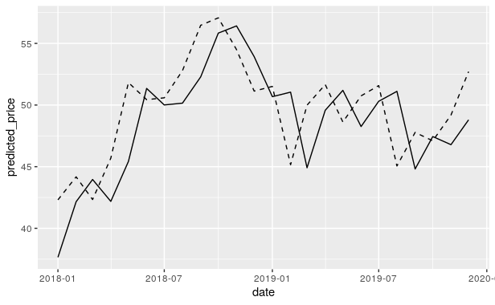

```r
ggplot(predictions) +
  geom_line(aes(x=date, y=predicted_price)) +
  geom_line(aes(x=date, y=mean_closing_price), linetype="dashed")
```